# Visualization of mouse L2/3 excitatory Patch-seq cells

Jeremy Miller

September 15, 2021

This notebook compares mouse FACs to Patch-seq data and visualizes the results. We take as input the set of mouse Patch-seq cells, as well as the initial cluster assignments.

If needed set the working directory: (e.g., `setwd("PATH_TO_DIRECTORY/patchseq_human_L23")`).

## Prepare the data

First load the required libraries and options and set directory locations.

```r
## Load libraries
suppressPackageStartupMessages({
  library(feather)
  library(dplyr)
  library(gplots)
  library(Seurat)
  library(ggplot2)
  library(cowplot)
  library(scrattch.hicat)
  library(future)
  library(ggbeeswarm)
  library(mfishtools) # getBetaScore
  library(pheatmap)
  library(VENcelltypes)
  library(WGCNA)
  library(matrixStats)
  library(Matrix)
  library(umap)
})
options(stringsAsFactors=FALSE)

## Prepare for extra memory usage
plan("multiprocess", workers = 4)
```

```r
options(future.globals.maxSize = 4000 * 1024^2)
```

Next, load the all the relevant data, which was calculated in a previous script.

```r
load("input_data_sets.RData")
load("complete_facs_data_sets.RData")
load("umap_coordinates.RData")
```

## Visualize Seurat-classified Patch-seq cells

Prior to this code, we have classified patch-seq cells using Seurat (https://satijalab.org/seurat/). This does NOT require performing clustering, but rather we took the clusters originally assigned in the VISp/ALM paper (Tasic 2018) and used these to map the Seurat data against. This was done for cells included in this study and in Gouwens et al 2020 (GABAergic interneurons), and for some unpublished deep-layer excitatory neurons. To do this, we first filtered genes (as done below), then we followed the standard pipeline (replacing VariableGenes with this filtered gene set). With this as background, we now want to plot these cells in the same space of the dissociated cells.

First, let’s do some pre-processing / filtering to exclude genes that are enriched in glial clusters or that are exceptionally higher in FACs relative to Patch-seq data. We also want to exclude sex and mitochondrial from consideration as markers.

```r
# First exclude mitochondrial and sex genes
isExclude <- sort(unique(c(sex_genes,mito_genes)))
excludeGn <- is.element(rownames(datPatchM),isExclude)

# Second find glial genes and exclude these from consideration.
clVISp   = factor(annoVISp_all$cluster_label)
names(clVISp) <- colnames(datVISp_all)
medians = get_cl_medians(datVISp_all,clVISp)
isUsed  = sort(unique(as.character(clVISp)))
isUsed  = isUsed[!(grepl("Low",isUsed)|grepl("Doublet",isUsed)|grepl("Batch",isUsed)|grepl("High",isUsed))]
isGlia  = isUsed[grepl("Astro ",isUsed)|grepl("Endo ",isUsed)|grepl("Microglia ",isUsed)|
                    grepl("Oligo ",isUsed)|grepl("OPC ",isUsed)|grepl("Oligo ",isUsed)|
                    grepl("PVM ",isUsed)|grepl("SMC ",isUsed)|grepl("VLMC ",isUsed)]
isUsed  = setdiff(isUsed,c(isGlia,"CR Lhx5","Meis2 Adamts19"))

maxUsed = apply(medians[,isUsed],1,max)
maxGlia = apply(medians[,isGlia],1,max)
#maxDiff = maxGlia/(maxUsed+0.1)
#glialGn = maxDiff>=2     # Exclude genes at least two-fold higher in at least one glial type compared with all other types
glialGn = maxGlia>maxUsed     # Exclude genes with maximal median expression in glia, to match human, even though many genes are lost

# Third, exclude genes with average expression at least four-fold higher in either FACS or patch-seq
platformGn = abs(rowMeans(datVISp)-rowMeans(datPatchM))>=2

# Finally, only keep genes that are expressed in both FACS and Patch-seq (log2(CPM+1)>=1 in 1% of the cells)
expressedGn = (rowSums(datVISp>=1)>(0.01*dim(datVISp)[2]))&(rowSums(datPatchM>=1)>(0.01*dim(datPatchM)[2]))

keepGenes <- (!(excludeGn|glialGn|platformGn))&(expressedGn)
mean(keepGenes)
```

```
[1] 0.31699
```

Only these genes will be used in the analysis below.

Data and meta-data set-up.

```r
## Basic data and metadata set-up
annoPatchM$scaled_depth <- annoPatchM$L23_depth_normalized
brain.data     <- cbind(datVISp[keepGenes,],datPatchM[keepGenes,])  # Include only genes subsetted above
brain.metadata <- data.frame(set=c(rep("FACs",dim(datVISp)[2]),rep("PatchSeq",dim(datPatchM)[2])),
 celltype = c(annoVISp$cluster_label,annoPatchM$cluster),   # Patch-seq cell type = patch-seq
 depth = c(rep(NA, dim(annoVISp)[1]),annoPatchM$scaled_depth))
rownames(brain.metadata) <- colnames(brain.data)

## Construct data set lists
brain      <- CreateSeuratObject(counts = brain.data, meta.data = brain.metadata)
brain.list <- SplitObject(object = brain, split.by = "set")
```

Calculate proportions and beta score for variable gene selection.

```r
cl        <- setNames(annoVISp$cluster_label,colnames(datVISp))
propExpr  <- get_cl_prop(datVISp[keepGenes,],cl)
betaScore <- getBetaScore(propExpr)
betaOut   <- data.frame(Gene=rownames(datVISp)[keepGenes],BetaScore=betaScore)
betaOut   <- betaOut[order(-betaScore),]
```

Variable feature selection (beta score replaces the default Seurat method and is also independent of the Patch-seq cells, except for the gene filtering step).

```r
nGenes      <- 2000
varFeatures <- betaOut$Gene[1:nGenes]

for (i in 1:length(x = brain.list)) {
  VariableFeatures(brain.list[[i]]) <- varFeatures
}
```

We now use these genes to make a combined brain set. *Note that this is for visualization and for comparison with other features, but that FACs reference alone was used for mapping.*

```r
dims          <- 10 # 30   # Seems to work better than the 30 pcs in human
k.filter      <- 50 # 100  # Need this because there are <200 patch-seq cells
set.seed(10)  # I don't think this is necessary, but just in case...
## Set up a integrated data set using Patch-seq and FACs data
brain.anchors    <- FindIntegrationAnchors(object.list = brain.list, dims = 1:dims, anchor.features = varFeatures, verbose = FALSE,
                                     k.filter = k.filter)
```

[output not shown]

```r
  # Note that we are providing anchor features
brain.integrated <- IntegrateData(anchorset = brain.anchors, dims = 1:dims, verbose = FALSE)
```

```
Adding a command log without an assay associated with it
```

```r
## Run the main integration analysis
DefaultAssay(object = brain.integrated) <- "integrated"
brain.integrated <- ScaleData(object = brain.integrated, verbose = FALSE)
```

```r
brain.integrated <- RunPCA(object = brain.integrated, npcs = dims, verbose = FALSE)
```

Predict UMAP coordinates of patch-seq data given the UMAP coordinates from FACs.

```r
data_patch <- FetchData(brain.integrated, vars=paste0("PC_",1:dims), cells=colnames(datPatchM), slot="scale.data")
data_FACS  <- FetchData(brain.integrated, vars=paste0("PC_",1:dims), cells=colnames(datVISp), slot="scale.data")

# Run umap from umap library
umap_FACs  <- umap(data_FACS) # Predict does not work with method="umap-learn" as far as I can tell
# Replace values with values from Seurat umap in initial analysis
umap_FACs$layout <- as.matrix(umap_mouseV)
# Predict patch-seq locations using "predict" function
umap_patch <- predict(umap_FACs,data_patch)
```

Calculate UMAP using Seurat. *These values will be over-written with the UMAP values calculated above.*

```r
brain.integrated <- RunUMAP(object = brain.integrated, reduction = "pca", dims = 1:dims, verbose = FALSE)
```

```
The default method for RunUMAP has changed from calling Python UMAP via reticulate to the R-native UWOT using the cosine metric
To use Python UMAP via reticulate, set umap.method to 'umap-learn' and metric to 'correlation'
This message will be shown once per session
```

```r
# Update the umap coordinates from above.
brain.integrated@reductions$umap@cell.embeddings <- rbind(umap_FACs$layout,umap_patch)
```

Plot the results in UMAP space.

```
Using `as.character()` on a quosure is deprecated as of rlang 0.3.0.
Please use `as_label()` or `as_name()` instead.
```

[figure not shown]

Plot the PCs for reference.

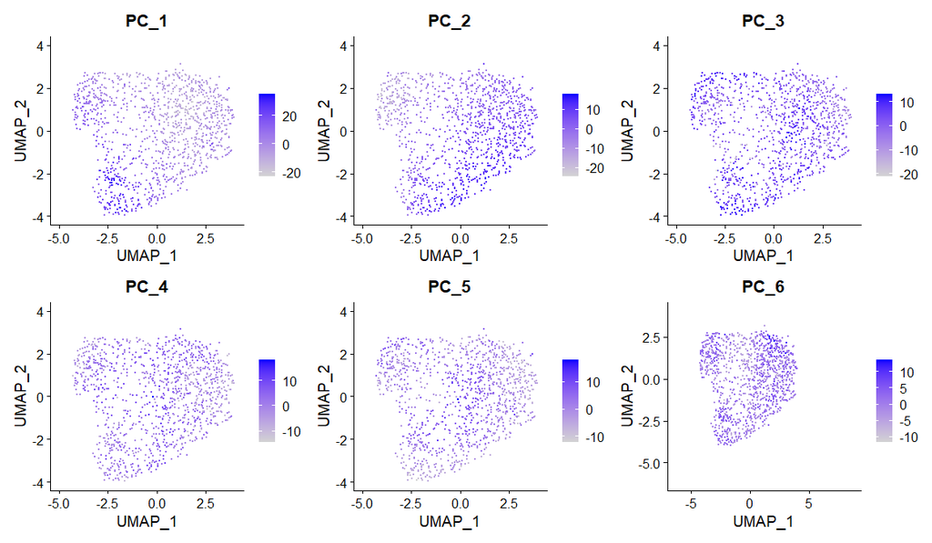

```r
features = paste0("PC_",1:6)
FeaturePlot(object = brain.integrated, reduction = "umap", pt.size = 0.5, features = features, ncol=3) + xlim(xl) + ylim(yl)
```

Plot some qc metrics for the Patch-seq cells only.

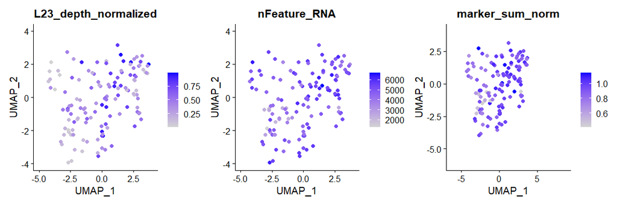

```r
biTmp  <- subset(brain.integrated, cells = colnames(datPatchM))
biTmp@meta.data <- cbind(biTmp@meta.data,as.data.frame(annoPatchM))
features2 <- c("L23_depth_normalized","nFeature_RNA","marker_sum_norm")
FeaturePlot(object = biTmp, reduction = "umap", pt.size = 2, features = features2, ncol=3) + xlim(xl) + ylim(yl)
```

```r
ggsave("qc_feature_umap_L23mouse.pdf",height=5,width=14)
```

## Compare properties with cluster calls and output results

First, we need to merge the meta-data into a single matrix.

```r
tAnnoPatch <- as.data.frame(annoPatchM)
rownames(tAnnoPatch) <- tAnnoPatch$SpecimenID

umap  <- FetchData(object = brain.integrated, vars = paste0('UMAP_',1:2))
umap  <- umap[colnames(datPatchM),]
colnames(umap) <- gsub("UMAP_","tUMAP_",colnames(umap))

tPcs  <- FetchData(object = brain.integrated, vars = paste0('PC_',1:dims))
tPcs  <- tPcs[colnames(datPatchM),]
colnames(tPcs) <- gsub("PC_","tPC_",colnames(tPcs))

metaPatch1 <- data.frame(SpecimenID = rownames(tAnnoPatch))
metaPatch  <- cbind(metaPatch1, tAnnoPatch, umap, tPcs)
metaPatch  <- metaPatch[,unique(colnames(metaPatch))]
```

Output the results.

```r
write.csv(metaPatch,"IVSCC_excitatory_L23mouse_March2020.csv",row.names=FALSE)
```

Now plot the results and significance values. Note that the cortical depth plots included in the manuscript were generated using the identical data to what is shown below, but using different plotting functions, axis ranges and cell type ordering. These plots are intended to get a feel for what is significantly different across cell types, including cortical depth.

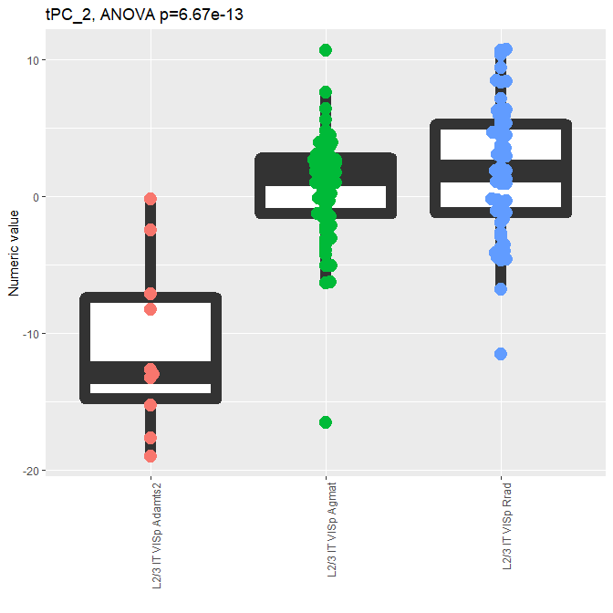

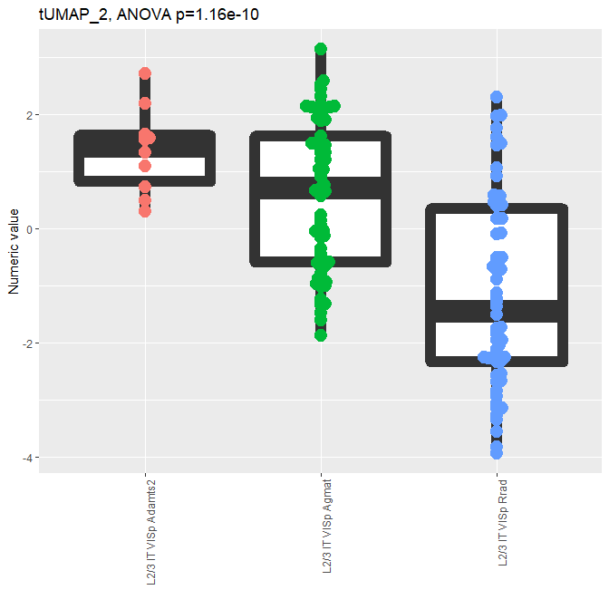

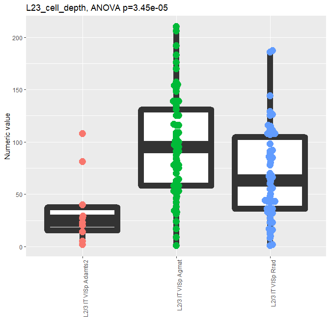

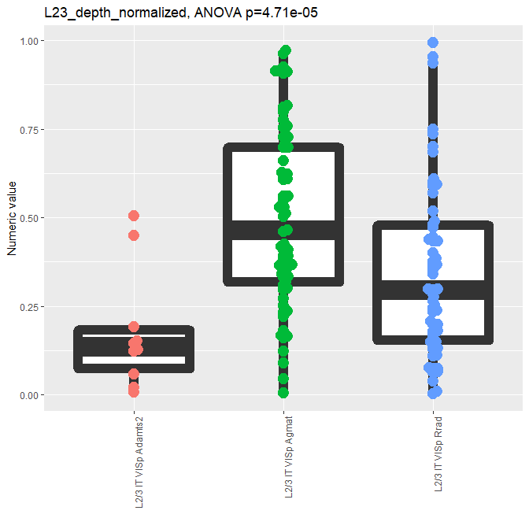

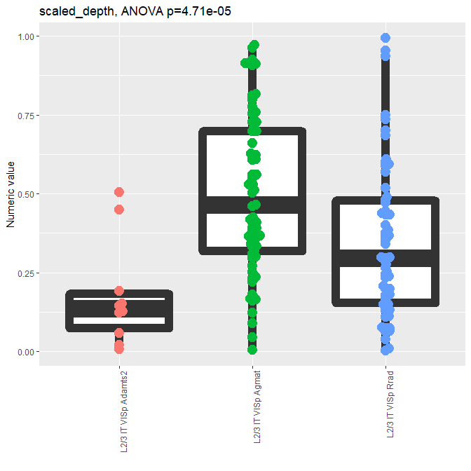

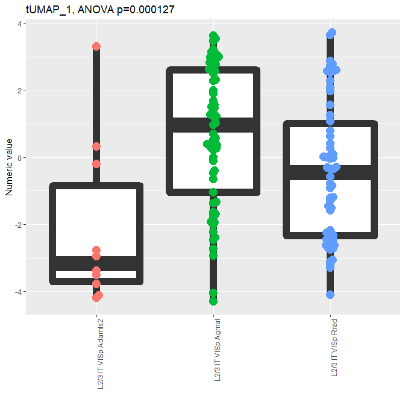

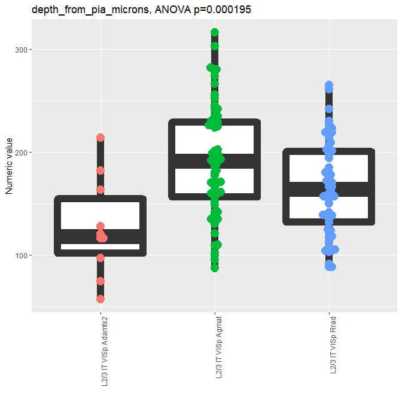

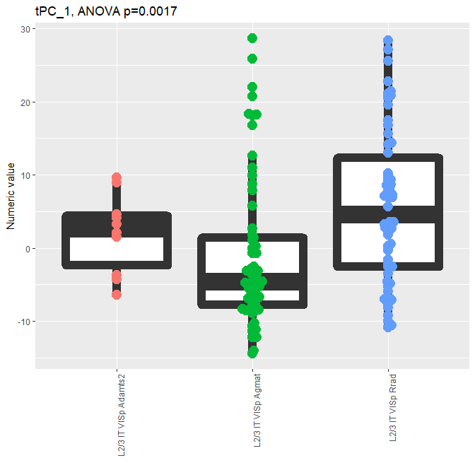

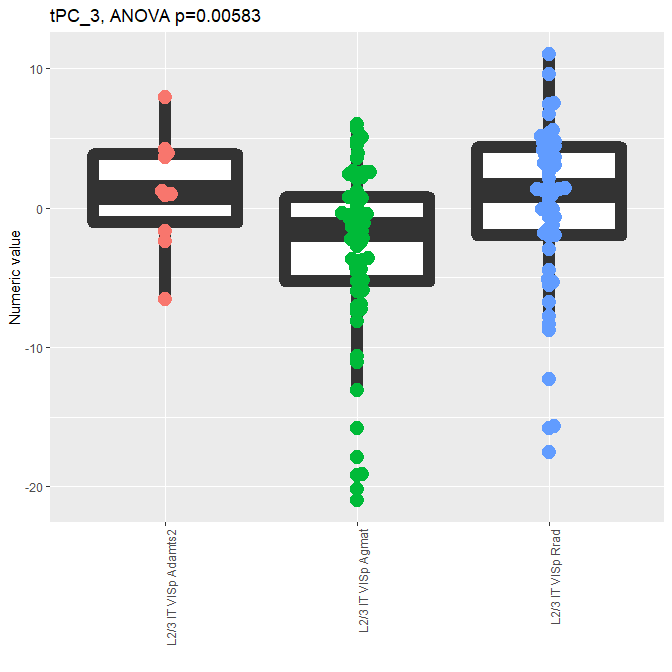

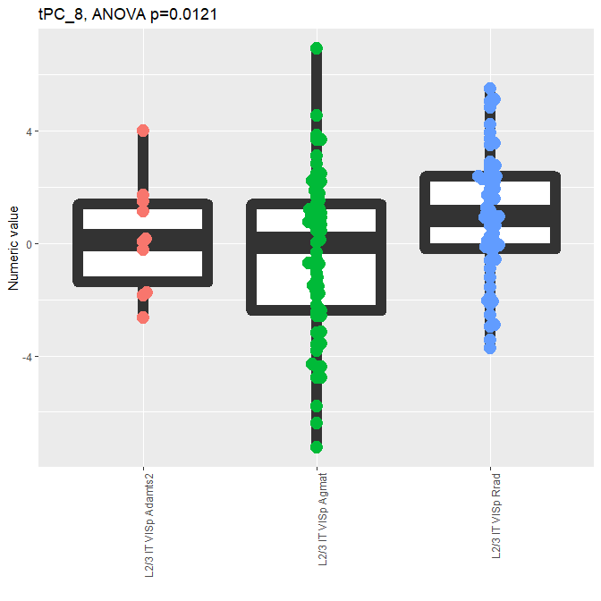

```r
kpSampP2 <- 1:dim(metaPatch)[1]  # USE ALL SAMPLES

classes <- NULL
for (i in 1:dim(metaPatch)[2]) classes <- c(classes,class(metaPatch[,i])[1])
annoPatchNum <- metaPatch[kpSampP2,(classes!="character")&(colSums(!is.na(metaPatch))>50)]
sCluster2    <- annoPatchM$cluster

getAnovaPvalforApply <- function(x,varLabels,varWeights=NULL){
  anovadat  = as.data.frame(cbind(varLabels,x))
  aov.out   = summary(aov(as.numeric(anovadat[,2])~anovadat[,1],data=anovadat,weights=varWeights))
  return(aov.out[[1]]$'Pr(>F)'[1])
}
anovaPval    <- apply(t(annoPatchNum),1,getAnovaPvalforApply,sCluster2)

plots <- list()
N     <- dim(annoPatchNum)[2]
for (i in 1:10){
 j    <- order(anovaPval)[i]
 dat  <- annoPatchNum[,j]
 kp   <- !is.na(dat)
 p    <- ggplot(mapping=aes(x=sCluster2[kp], y=dat[kp], size=1)) +
    geom_boxplot() +
    geom_beeswarm(aes(color=sCluster2[kp]))+
    theme(axis.text.x = element_text(angle = 90, vjust = 1, hjust=1)) +
    theme(legend.position="none") + labs(x='',y="Numeric value") +
    ggtitle(paste0(names(anovaPval[j]),", ANOVA p=",signif(anovaPval[j],3)))
 plots[[i]] <- ggplotGrob(p)
}
plots2 <- plots
class(plots2) <- c("arrangelist", class(plots2))
plots2
```

```r
for (i in 11:N){
 j    <- order(anovaPval)[i]
 dat  <- annoPatchNum[,j]
 kp   <- !is.na(dat)
 p    <- ggplot(mapping=aes(x=sCluster2[kp], y=dat[kp], size=1)) +
    geom_boxplot() +
    geom_beeswarm(aes(color=sCluster2[kp]))+
    theme(axis.text.x = element_text(angle = 90, vjust = 1, hjust=1)) +
    theme(legend.position="none") + labs(x='',y="Numeric value") +
    ggtitle(paste0(names(anovaPval[j]),", ANOVA p=",signif(anovaPval[j],3)))
 plots[[i]] <- ggplotGrob(p)
}
class(plots) <- c("arrangelist", class(plots))
ggsave("allInfo_vs_cluster_L23excMouse_seurat.pdf", plots)
```